# ESM 204 Assignment 4

Quin Smith & Trent Buchanan

5/22/2021

```r
#read data
dam <- read.csv(here("data/damages.csv"))
warm <- read.csv("data/warming.csv")
```

## Question 1

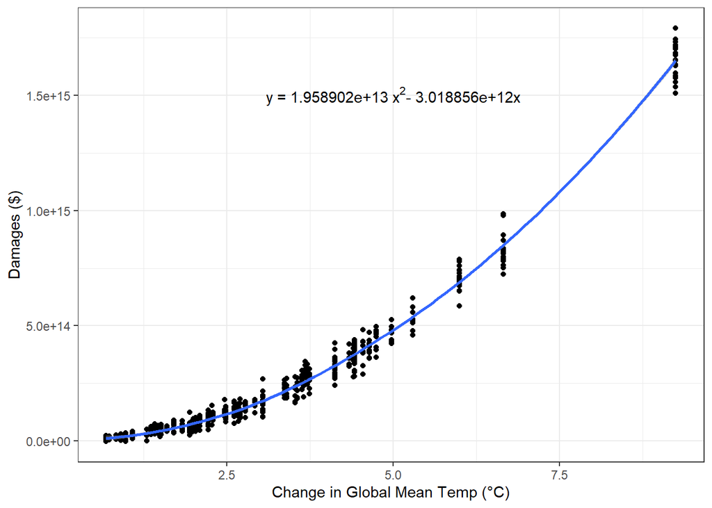

**Figure 1:** Esimated Cost Function equation overlayed above dollar value of damages versus change in global mean temperature.

```r
#Question 1
#dam^2
dam <- dam %>%
  mutate(warm2 = warming^2)

#dam_lm
dam_lm <- lm(damages ~ warming + warm2, data=dam)

dam_lm[["coefficients"]][["(Intercept)"]] <- 0

#plot
dam_plot <- ggplot(data=dam) +
  geom_point(aes(x=warming, y=damages)) +
  stat_smooth(data=dam_lm, aes(x=warming, y=damages)) +
  labs(x = "Change in Global Mean Temp (°C)", y = "Damages ($)") +
  annotate(geom = "text", x=5.0, y=1500000000000000, label= expression("y = 1.958902e+13 x"^2*"- 3.018856e+12x" )) +
  theme_bw()

dam_plot
```

## Question 2

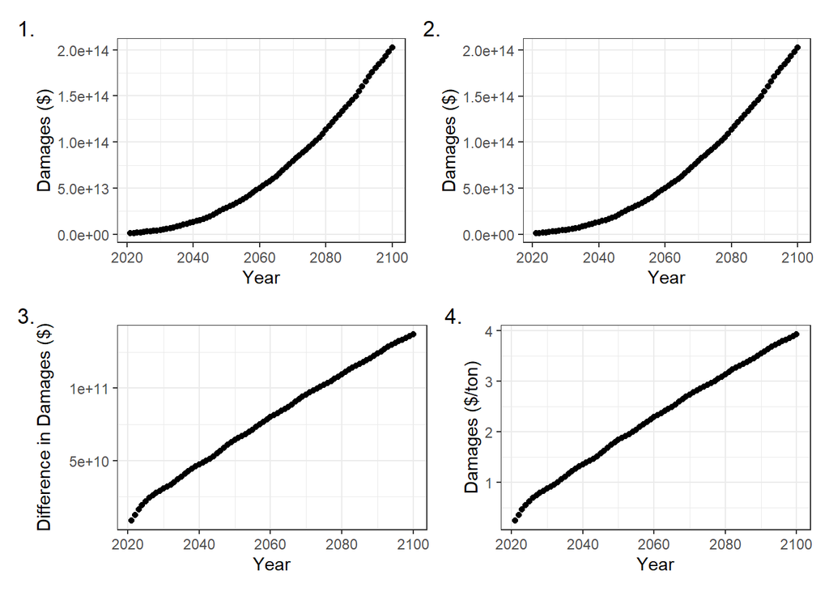

**Figure 2: 1.** Damages over time without pulse **2.** Damages over time with pulse **3.** Differences in damages over time arising from the pulse **4.** Difference in damages over time from the pulse per ton of CO2.

```r
#Question 2
x <-dam_lm[["coefficients"]][["warming"]]
x2 <-dam_lm[["coefficients"]][["warm2"]]
int <-dam_lm[["coefficients"]][["(Intercept)"]]

warm <- warm %>%
  mutate(dam_base = (warming_baseline*x) + ((warming_baseline)^2*x2) + int,
         dam_pulse = (warming_pulse*x) + ((warming_pulse)^2*x2) + int,
         dam_diff = dam_pulse - dam_base,
         dam_ton = dam_diff/35000000000)

#graphs
dam_base_plot <- ggplot(data = warm) +
  geom_point(aes(x=year, y=dam_base)) +
  labs(x = "Year", y = "Damages ($)") +
  theme_bw()

dam_pulse_plot <- ggplot(data = warm) +
  geom_point(aes(x=year, y=dam_pulse)) +
  labs(x = "Year", y = "Damages ($)") +
  theme_bw()

dam_diff_plot <- ggplot(data = warm) +
  geom_point(aes(x=year, y=dam_diff)) +
  labs(x = "Year", y = "Difference in Damages ($)") +
  theme_bw()

dam_ton_plot <- ggplot(data = warm) +
  geom_point(aes(x=year, y=dam_ton)) +
  labs(x = "Year", y = "Damages ($/ton)") +
  theme_bw()

q2_patched <- (dam_base_plot + dam_pulse_plot) / (dam_diff_plot + dam_ton_plot)

q2_patched + plot_annotation(tag_levels = "1", tag_suffix = ".")
```

## Question 3

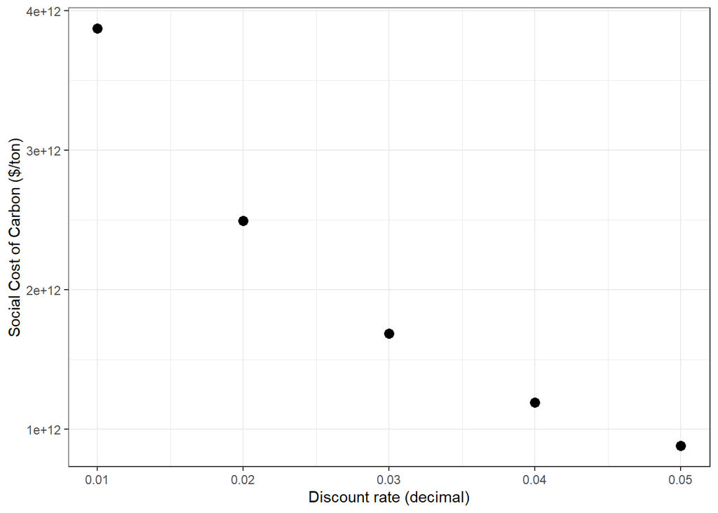

**Figure 3:** Social Cost of Carbon versus a range of discount rates (1-5%).

```r
#Question 3
warm <- warm %>%
  mutate(scc1 = dam_diff/ (1+0.01)^X,
         scc2 = dam_diff/ (1+0.02)^X,
         scc3 = dam_diff/ (1+0.03)^X,
         scc4 = dam_diff/ (1+0.04)^X,
         scc5 = dam_diff/ (1+0.05)^X) %>%
  mutate(scc1_sum = sum(scc1),
         scc2_sum = sum(scc2),
         scc3_sum = sum(scc3),
         scc4_sum = sum(scc4),
         scc5_sum = sum(scc5))

scc_df <- data.frame(c(0.01, 0.02, 0.03, 0.04, 0.05)) %>%
  cbind(c(warm$scc1_sum[1], warm$scc2_sum[1], warm$scc3_sum[1], warm$scc4_sum[1], warm$scc5_sum[1]))

colnames(scc_df) <- c("rate", "scc_sum")

scc_plot <- ggplot(data = scc_df) +
  geom_point(aes(x=rate, y=scc_sum), size = 3) +
  labs(y = "Social Cost of Carbon ($/ton)", x = "Discount rate (decimal)") +
  theme_bw()

scc_plot
```

## Question 4

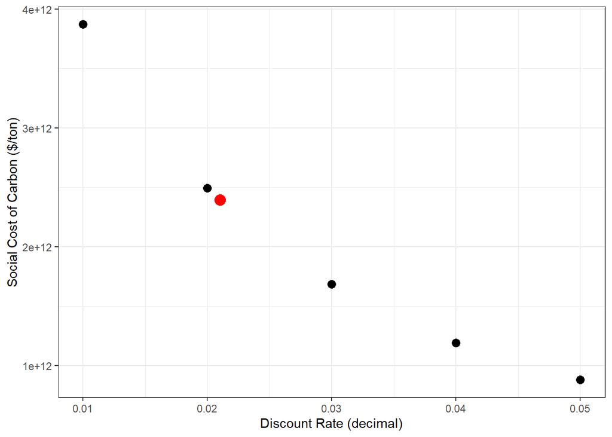

**Figure 4:** Social Cost of Carbon versus a range of discount rates (1-5%). The red point indicates the Social Cost of Carbon using the Ramsey Rule equation, which was calulated to be **$2.393246e+12** at a discount rate of **2.1% (0.021)**.

```r
#Question 4
rams <- 0.001+(2*0.01)

warm <- warm %>%
  mutate(sccrams = dam_diff/ (1+rams)^X) %>%
  mutate(sccrams_sum = sum(sccrams))

sccrams_df <- data.frame(c(0.01, 0.02, 0.03, 0.04, 0.05, rams)) %>%
  cbind(c(warm$scc1_sum[1], warm$scc2_sum[1], warm$scc3_sum[1], warm$scc4_sum[1], warm$scc5_sum[1], warm$sccrams_sum[1]))

colnames(sccrams_df) <- c("rate", "scc_sum")

rams_pt <- subset(sccrams_df, rate == rams)

scc_plotq4 <- ggplot(data = scc_df) +
  geom_point(aes(x=rate, y=scc_sum), size = 3) +
  geom_point(data = rams_pt, aes(x=rate, y=scc_sum), color = "red", size = 4) +
  labs(x = "Discount Rate (decimal)", y = "Social Cost of Carbon ($/ton)") +
  theme_bw()

scc_plotq4
```

## Question 5

```r
#Question 5

#policy A
warm5A <- warm %>%
  select(X, year, warming_baseline, dam_base) %>%
  mutate(dam_base_sc = (dam_base/ (1+0.02)^X),
         warming_1.5 = warming_baseline * 1.5,
         dam_1.5 = (warming_1.5*x) + ((warming_1.5)^2*x2),
         dam_1.5_sc = (dam_1.5/ (1+0.02)^X))

dam_base_sum <- sum(warm5A$dam_base_sc) * .5
dam_1.5_sum <- sum(warm5A$dam_1.5_sc) * .5

expect_val_A <- dam_base_sum + dam_1.5_sum

#policy B
warm5B <- warm %>%
  select(X, year, warming_baseline) %>%
  mutate(warming = case_when(
    year < 2050 ~ warming_baseline,
    year >= 2050 ~ 1.29),
    dam_b = (warming*x) + ((warming)^2*x2),
    dam_b_sc = dam_b/ (1+0.02)^X
  )

expect_val_B <- sum(warm5B$dam_b_sc)

#what is X for policy B?
X_polB <- expect_val_A - expect_val_B
```

The expected present value of damages up to 2100 under **Policy A** is **$2.9317944^{15}**.

The expected present value of damages up to 2100 under **Policy B** is **$7.0987961^{14}**.

In order to make economic sense, the cost of undertaking **Policy B (X)** would have to be **$2.2219148^{15}** (the difference between the expected values of Policies A and B) to pursue **Policy B** instead of the business-as-usual approach of **Policy A**. Any additional cost would lead to Policy A becoming the more economically sensible option.

This answer would change if society was risk averse. A risk averse society would be willing to pay a maximum cost even higher than $2.2219148^{15} to implement Policy B. This is because to a risk averse society, the utility of a guaranteed reduction of global temperature change at the cost of $2.2219148^{15} is higher than the utility of a risky option at no cost. In other words, a risk averse society would be willing to pay some higher value of X to implement the less risky option of Policy B.